# Lab 12: Solutions

1. These exercises are based on a famous kaggle competition in which competitors predict who lives and who dies on the Titanic. Download the data set from [this](https://www.dropbox.com/s/eg6kack8wmlqmhg/titanic_train.csv) address, and load it into R. It has the following variables:
- `Survived` Survival (0 = No; 1 = Yes)
- `Pclass` Passenger Class (1 = 1st; 2 = 2nd; 3 = 3rd)
- `Name` Name
- `Sex` Sex
- `Age` Age (in years)
- `SibSp` Number of Siblings/Spouses Aboard
- `Parch` Number of Parents/Children Aboard
- `Ticket` Ticket Number
- `Fare` Passenger Fare
- `Cabin` Cabin
- `Embarked` Port of Embarkation (C = Cherbourg; Q = Queenstown; S = Southampton)

```r
library(tidyverse)
library(rpart)
library(rpart.plot)
library(randomForest)
train <- read_csv("../titanic_train.csv")
```

2. Which variables do you think may be good predictors of the survival on the Titanic? Create two or three graphs similar to those in lab 11 (the data exploration lab). (Hint1: You may want to turn the `Survived` variable into a factor using the `factor()` function. Hint2: You may want to add `+ geom_jitter()` to plots involving qualitative variables.)

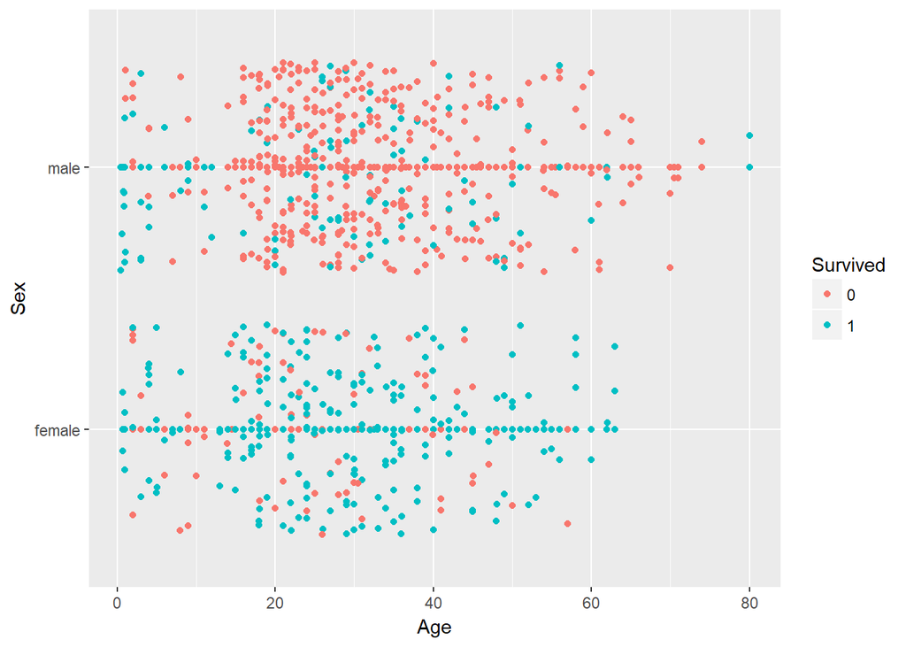

```r
train$Survived <- factor(train$Survived)
train$Sex <- factor(train$Sex)
ggplot(train, aes(x=Age, y=Sex, color=Survived)) + geom_point()  + geom_jitter()
```

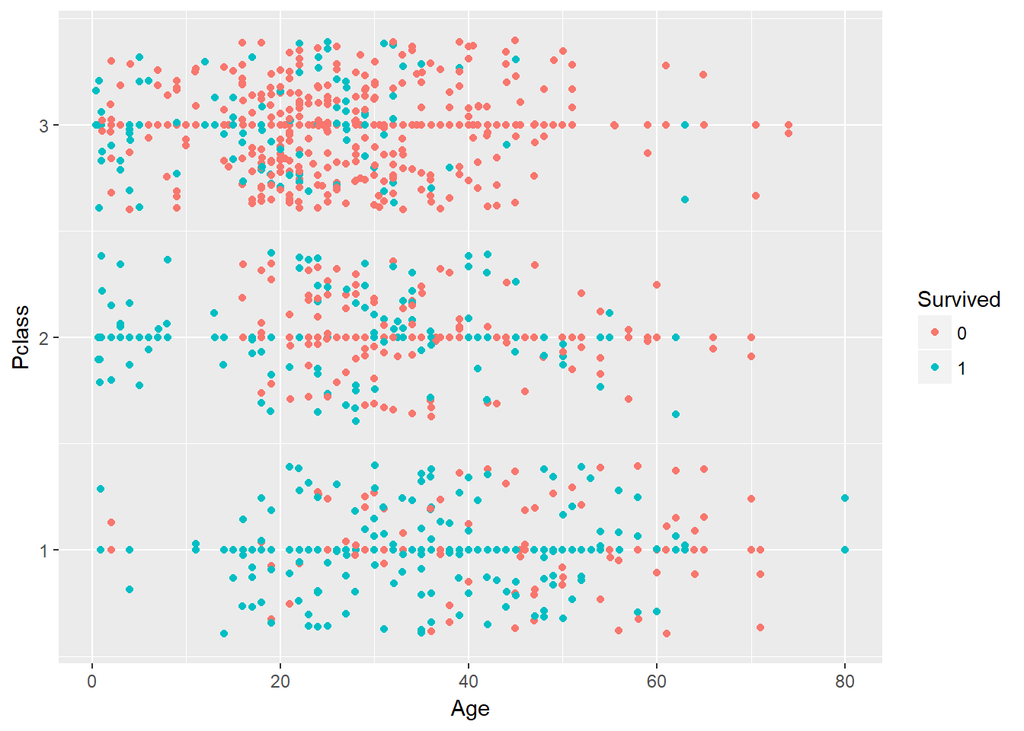

```r
ggplot(train, aes(x=Age, y=Pclass, color=Survived)) + geom_point()  + geom_jitter()
```

In the above plot I look at the effect of passenger class and age. It is clear that survival was much less likely among passengers in the third class. Also, it appears that children in the first and particularly in the second class were much more likely to survive than children in the third class.

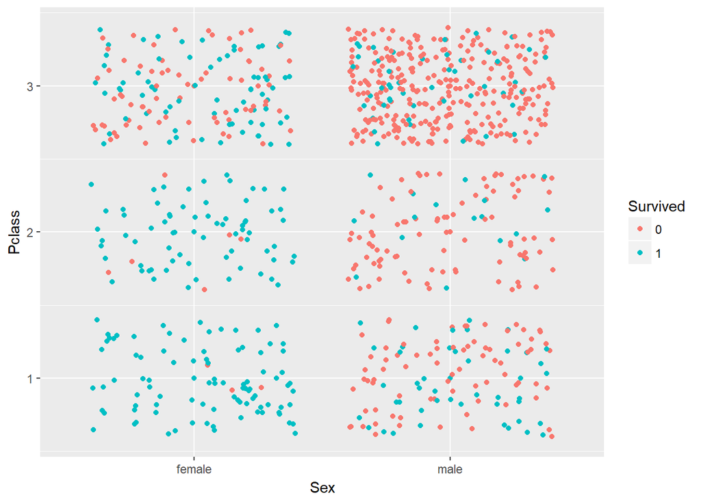

```r
ggplot(train, aes(x=Sex, y=Pclass, color=Survived)) + geom_point()  + geom_jitter()
```

3. Estimate a decision tree predicting survival using age and sex as predictors. Describe your results.

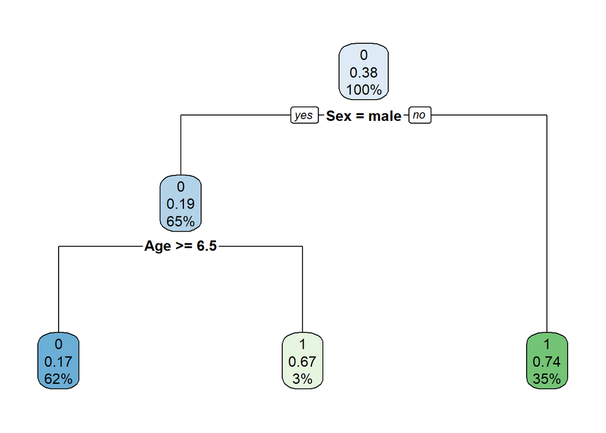

```r
tree <- rpart(Survived ~ Age + Sex, data=train)
rpart.plot(tree)
```

The algorithm says that women survive. Men survive if they are 6.5 years old or younger.

4. Estimate a decision tree using age, sex and passenger class. Describe your results.

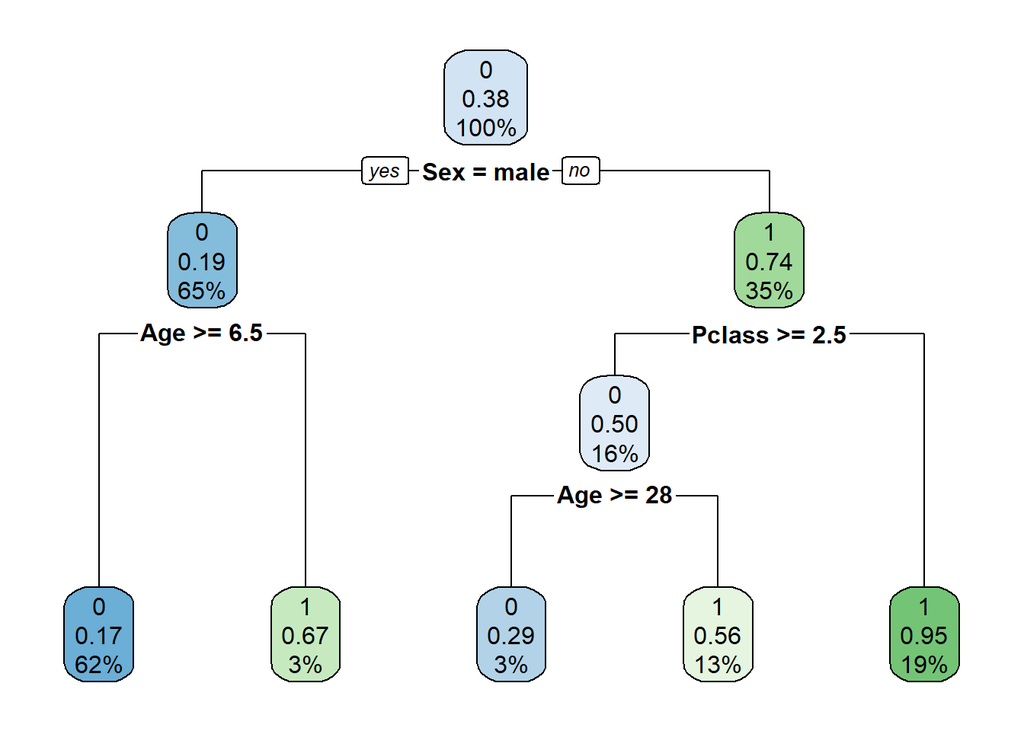

```r
tree <- rpart(Survived ~ Age + Sex + Pclass, data=train, minsplit=50)
rpart.plot(tree)
```

Again, men died unless they were boys younger than 6 and a half. Women in first and second class survived. Women in third class died unless they were younger than 28.

5. Estimate your own decision tree with your own set of predictors (you are, of course, free to include the predictors we used above).

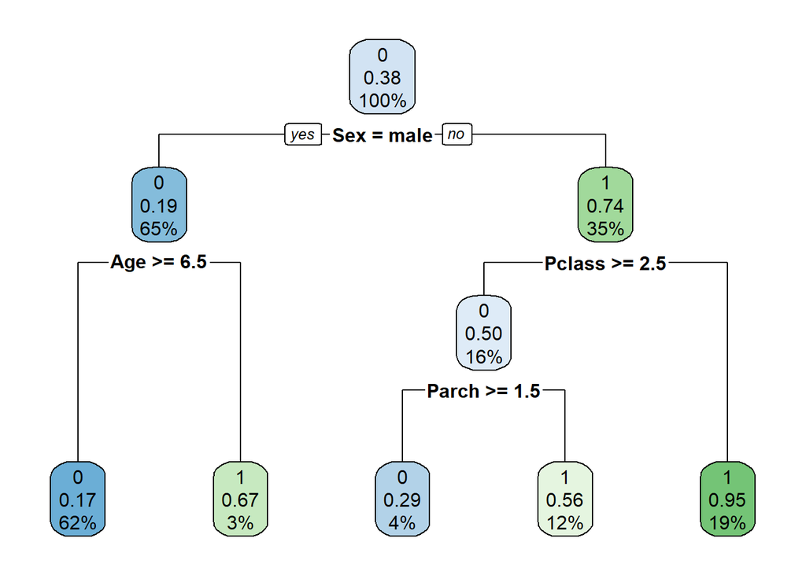

```r
tree <- rpart(Survived ~ Age + Sex + Pclass + SibSp + Parch , data=train, minsplit=60)
rpart.plot(tree)
```

Again, men died unless they were boys younger than 6 and a half. Women in first and second class survived. Women in third class died unless they had at most one parent or child on board. (Women in third class who had more than 1 parent or child on board died. Perhaps, larger families tried to stay together and ended up dying.)

```r
test <- read_csv("https://www.dropbox.com/s/x7vt6nrankfj0kz/titanic_test.csv?raw=1")
test$Sex <- as.factor(test$Sex)
test$Survived_pred <- predict(tree, test, type="class")
table(test$Survived_pred)
```

```
##
##   0   1
## 270 148
```

7. Even though *we* don’t know the fate of the passengers in the test data set, Kaggle does. In fact, Kaggle will evaluate our predictions and tell us how many we got right. Moreover, Kaggle will compare the accuracy of our predictions to those of other participants in the competition. All we have to do is register with Kaggle and create a .csv file that contains two columns: `PassengerId` and `Survived`, where `Survived` contains our predictions: 0 for did not survive, and 1 for survived. You can use `write_csv()` to make that `.csv` file (make sure to `select()` only `PassengerId` and `Survived`. Submit your predictions to Kaggle and report on your accuracy and rank compared to other participants. You can make up to 5 submissions per day if you would like to experiment with different models, and improve your submission. Feel free to try `randomForest`. Take a screenshot of your submission result, and attach it to your lab. I will pay five dollars to the team with the highest rank. Good luck!

```r
train$Age <- ifelse(is.na(train$Age), mean(train$Age, na.rm = TRUE), train$Age)
test$Age <- ifelse(is.na(test$Age), mean(test$Age, na.rm = TRUE), test$Age)
rf <- randomForest(Survived ~ Age + Sex + Pclass + Parch + SibSp , data=train, na.action=na.omit)
test$Survived <- predict(rf, test, type="class")
write_csv(select(test, PassengerId, Survived), "Submission.csv")
```

The above model generated accuracy of 77.511% on the `test` data, which as of February 4 ranks in the 5,000s.